# finaltutorial

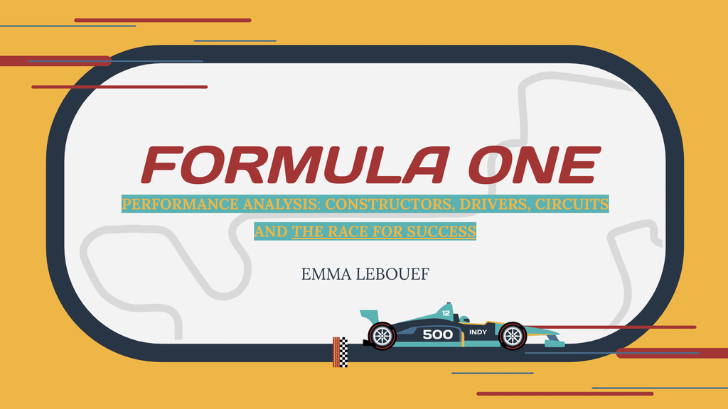

[Github website](https://emmalebouef.github.io)

**Goals of This Project:**

1. **Determine which performance metrics are determinants of winning races.**
   > - I will utilize a regression model using historical data on each circuit to predict how a particular driver will do given their success in a given season. Essentially, I will be utilzing historical data of all drivers at a particular race, to predict how a similar driver may do at the same particular race
2. **Determine the role that constructors play in pit stops, qualifiers, and ultimately winning races. Utilize historical data, to predict which constructor will win based on their performance in a given season**
   > - I will utilize another regression model using historical data on each of the constructors. I will analyze how the constructors have performed at similar circuits over time and extrapolate said analysis to build a prediciton model that will estimate how the constructors will do based on the upcoming race schedule.

**Data Sets Overview:**

1. **circuits.csv** : *This dataset gives an overview of the different circuits within Formula One and their geographical information. A circuit is the track where a Formula One race occurs*
2. **constructor_results.csv** : *This dataset summarizes how each constructor did at each race and how many points they received.*
3. **constructor_standings.csv** : *This dataset highlights how each constructor did at specific races as well as the points their team received for said standings*
4. **constructors.csv** : *This dataset gives information on the different constructors within Formula One, their specific ID, and nationality. A constructor in Formula One is a company that designs and builds the race cars. Each team has a unique constructor*
5. **driver_standings.csv** : *This dataset illustrates the outcomes of each race. It shows how each driver did at specific races and how many points were awarded*
6. **drivers.csv** : *This dataset gives detailed information on all Formula One drivers for the past 70+ years. Within this dataset, there is information on nationality as well as age.*
7. **lap_times.csv** : *This dataset details each driver and how they performed each lap of every race. Each row signifies how a specific driver performed for each lap. We are given position after completing the lap as well as the time of lap*
8. **pit_stops.csv** : *This dataset provides information about all pitstops within the races. The pitstop dataset provides detailed information on stop length, what lap the stop occurred, and which driver was stopping.*
9. **qualifying.csv** : *To determine grid placement on race day, drivers compete in qualifying rounds on Saturday. This dataset details how each driver did at qualifiers, the overall time for each lap, and the placement earned for Sunday's race*
10. **races.csv** : *This dataset gives specific IDs to each race within Formula One between 1950-2022. The dataset has information on the circuit, what date the race was on, and even what time the race began*
11. **results.csv** : *This dataset summarizes pertinent information regarding the results of each Formula One race. Within the dataset, we can see where each driver started, where they finished and their fastest lap time*
12. **seasons.csv** : *This dataset provides a quick Wikipedia link for pertinent information on each Formula One Season.*
13. **sprint_results.csv** : *Sprint races are new to Formula One. They are not offered at every race but only typically at 'big' races. Only 1/3 the time of a normal race, the drivers compete in a 'mock race' to earn more points for their team and learn the track. This dataset captures important timing and placing metrics for the recent sprint races.*
14. **status.csv** : *This is a foreign key table that provides text explanations for the different race statuses*

**Data Set Citations**

1. I found all of these datasets on [Kaggle](https://www.kaggle.com/datasets/rohanrao/formula-1-world-championship-1950-2020?select=sprint_results.csv). The user who posted these datasets cleaned the data and compiled each table from http://ergast.com/mrd/

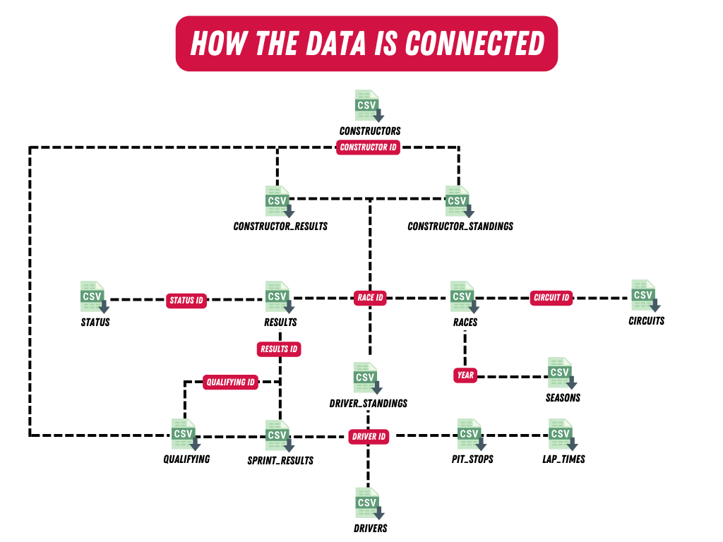

# **Establishing a Viable Workspace**

```python
# mounting my google drive
from google.colab import drive
drive.mount('/content/drive')
# changing the directory to my folder designated for this project
%cd /content/drive/My Drive/TU/SEMESTERS/f2022/data_final_proj
```

```
/content/drive/My Drive/TU/SEMESTERS/f2022/data_final_proj
```

```python
# importing important packages I will need
import matplotlib.pyplot as plt
import pandas as pd
!pip install geopandas
import geopandas as gpd
import numpy as np
import requests
```

```
     |████████████████████████████████| 1.1 MB 5.4 MB/s
     |████████████████████████████████| 16.6 MB 92 kB/s
     |████████████████████████████████| 7.8 MB 69.9 MB/s
```

```python
# reading each of the datasets into a dataframe
circuits = pd.read_csv("/content/drive/MyDrive/TU/SEMESTERS/f2022/data_final_proj/circuits.csv")
constructor_results = pd.read_csv("/content/drive/MyDrive/TU/SEMESTERS/f2022/data_final_proj/constructor_results.csv")
constructor_standings= pd.read_csv("/content/drive/MyDrive/TU/SEMESTERS/f2022/data_final_proj/constructor_standings.csv")
constructors = pd.read_csv("/content/drive/MyDrive/TU/SEMESTERS/f2022/data_final_proj/constructors.csv")
driver_standings = pd.read_csv("/content/drive/MyDrive/TU/SEMESTERS/f2022/data_final_proj/driver_standings.csv")
drivers = pd.read_csv("/content/drive/MyDrive/TU/SEMESTERS/f2022/data_final_proj/drivers.csv")
lap_times = pd.read_csv("/content/drive/MyDrive/TU/SEMESTERS/f2022/data_final_proj/lap_times.csv")
pit_stops = pd.read_csv("/content/drive/MyDrive/TU/SEMESTERS/f2022/data_final_proj/pit_stops.csv")
qualifying = pd.read_csv("/content/drive/MyDrive/TU/SEMESTERS/f2022/data_final_proj/qualifying.csv")
races = pd.read_csv("/content/drive/MyDrive/TU/SEMESTERS/f2022/data_final_proj/races.csv")
results = pd.read_csv("/content/drive/MyDrive/TU/SEMESTERS/f2022/data_final_proj/results.csv")
seasons = pd.read_csv("/content/drive/MyDrive/TU/SEMESTERS/f2022/data_final_proj/seasons.csv")
sprint_results = pd.read_csv("/content/drive/MyDrive/TU/SEMESTERS/f2022/data_final_proj/sprint_results.csv")
status = pd.read_csv("/content/drive/MyDrive/TU/SEMESTERS/f2022/data_final_proj/status.csv")
```

# **lap_times dataframe**

```python
lap_times = lap_times.rename(columns={"time": "lap_time", "milliseconds": "lap_in_milli", "position" : "position_after_lap"})
# because we cannot do any calculations with the lap_time, we are going to delete this column and opt to do all calculations with lap times in milliseconds
lap_times = lap_times.drop(columns=['lap_time'])
lap_times
```

|  | raceId | driverId | lap | position_after_lap | lap_in_milli |
| --- | --- | --- | --- | --- | --- |
| 0 | 841 | 20 | 1 | 1 | 98109 |
| 1 | 841 | 20 | 2 | 1 | 93006 |
| 2 | 841 | 20 | 3 | 1 | 92713 |
| 3 | 841 | 20 | 4 | 1 | 92803 |
| 4 | 841 | 20 | 5 | 1 | 92342 |
| ... | ... | ... | ... | ... | ... |
| 528780 | 1086 | 842 | 65 | 13 | 85989 |
| 528781 | 1086 | 842 | 66 | 12 | 85187 |
| 528782 | 1086 | 842 | 67 | 12 | 107355 |
| 528783 | 1086 | 842 | 68 | 12 | 97587 |
| 528784 | 1086 | 842 | 69 | 12 | 89072 |

528785 rows × 5 columns

```python
# All of the variables within this dataset are quantiative
# This makes sense for the types of data that we are dealing with. All Ids, positions, and times should be integers and we should be able to perform calculations using them
lap_times.dtypes
```

```
raceId                int64
driverId              int64
lap                   int64
position_after_lap    int64
lap_in_milli          int64
dtype: object
```

```python
# What is the relationship between how far in the race a driver is and their lap time?
lap_times.corr()
# There is a slight negativve correlation between lap time in milliseconds and lap
# This indicates that laps towards the end of the race are slightly faster than laps at the beginning of the race
# This may be the result of many factors, one being the inventive to win becoming more pressing in the final laps
```

|  | raceId | driverId | lap | position_after_lap | lap_in_milli |
| --- | --- | --- | --- | --- | --- |
| raceId | 1.000000 | 0.678799 | 0.008016 | 0.067379 | 0.043801 |
| driverId | 0.678799 | 1.000000 | 0.003528 | 0.189607 | 0.023565 |
| lap | 0.008016 | 0.003528 | 1.000000 | -0.129794 | -0.071714 |
| position_after_lap | 0.067379 | 0.189607 | -0.129794 | 1.000000 | 0.027247 |
| lap_in_milli | 0.043801 | 0.023565 | -0.071714 | 0.027247 | 1.000000 |

# **pit_stops dataframe**

```python
pit_stops = pit_stops.rename(columns={"time" : "time_when_stopped", "milliseconds": "stop_in_milli", "stop" : "stop_#"})
# we will drop the duration of stop in minutes and opt to use the duration of stop in milliseconds as it is easier to use for the purposes of this project
pit_stops = pit_stops.drop(columns=['duration'])
pit_stops
```

|  | raceId | driverId | stop_# | lap | time_when_stopped | stop_in_milli |
| --- | --- | --- | --- | --- | --- | --- |
| 0 | 841 | 153 | 1 | 1 | 17:05:23 | 26898 |
| 1 | 841 | 30 | 1 | 1 | 17:05:52 | 25021 |
| 2 | 841 | 17 | 1 | 11 | 17:20:48 | 23426 |
| 3 | 841 | 4 | 1 | 12 | 17:22:34 | 23251 |
| 4 | 841 | 13 | 1 | 13 | 17:24:10 | 23842 |
| ... | ... | ... | ... | ... | ... | ... |
| 9294 | 1086 | 855 | 2 | 51 | 16:17:20 | 28218 |
| 9295 | 1086 | 852 | 3 | 51 | 16:17:46 | 22128 |
| 9296 | 1086 | 844 | 3 | 54 | 16:20:03 | 21544 |
| 9297 | 1086 | 849 | 3 | 56 | 16:24:42 | 28777 |
| 9298 | 1086 | 825 | 3 | 67 | 16:40:35 | 23147 |

9299 rows × 6 columns

```python
pit_stops.dtypes
# All of the variables in this dataset are quantitative except for time_when_stopped
# I cannot figure out how to turn this to date time becuase the data for seconds is reported in decimals and that is not an accepted argument
```

```
raceId                int64
driverId              int64
stop_#                int64
lap                   int64
time_when_stopped    object
stop_in_milli         int64
dtype: object
```

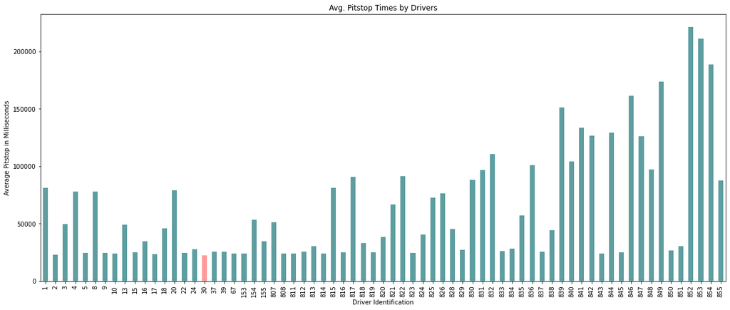

```python
# Whats the relationship between each driver and their average pitstop time?
#Creating a larger figure size so that my graph is readable and not smushed
plt.figure(figsize = (20, 8))
#Grouping the data by DriverId and taking the average pit stop in millieconds for each driver
pit_stops.groupby("driverId")["stop_in_milli"].mean()
#Plotting the relationship between Driver and pitstop
ax = pit_stops.groupby("driverId")["stop_in_milli"].mean()
#Indicating which driver had the lowest average pitstop
ax = ax.plot.bar(color=np.where(ax==ax.min(), '#ff9999','cadetblue'))
ax.set_xlabel("Driver Identification")
ax.set_ylabel("Average Pitstop in Milliseconds")
ax.set_title("Avg. Pitstop Times by Drivers")
# This graph shows us that there is great range in the average pitstops between different drivers
```

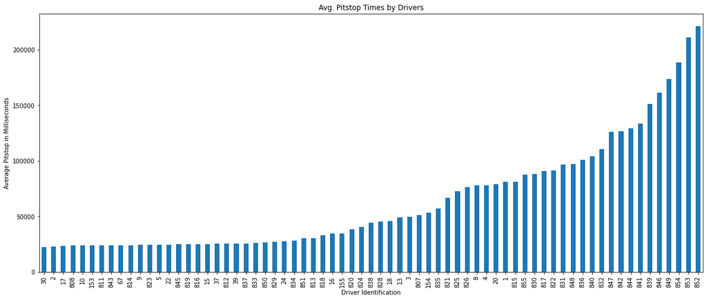

```python
# This graph shows us that while there is great range in the average pitstop times, there seems to be quite a large group with similar times at the bottom
# This could indicate that over the years, pitstop time has gotten better and thus drivers within the last five years have similar average pitstops
plt.figure(figsize = (20, 8))
ax2 = pit_stops.groupby("driverId")["stop_in_milli"].mean()
#Indicating which driver had the lowest average pitstop
ax2 = ax2.sort_values().plot.bar()
ax2.set_xlabel("Driver Identification")
ax2.set_ylabel("Average Pitstop in Milliseconds")
ax2.set_title("Avg. Pitstop Times by Drivers")
```

**Goals for the pit_stops data frame going forward**

- *Group driver Ids by constructor and see if pitstop average is similar within constructors*
- *Add an additional year component to the graph and see if the reduction in average pitstop time has to do with technological advancements over the years*